# Risk Factor Analysis

## Outcome Variable

**Outcome Variable:** sstunted

## Predictor Variables

**Intervention Variable:** birthlen

**Adjustment Set:**

- arm
- sex
- W_mage
- meducyrs
- feducyrs
- vagbrth
- single
- brthmon
- W_parity
- delta_W_mage
- delta_meducyrs
- delta_feducyrs
- delta_vagbrth
- delta_single
- delta_brthmon
- delta_W_parity

## Stratifying Variables

The analysis was stratified on these variable(s):

- agecat
- studyid
- country

## Data Summary

| agecat | studyid | country | birthlen | sstunted | n_cell | n |
| --- | --- | --- | --- | --- | --- | --- |
| Birth | CMC-V-BCS-2002 | INDIA | >=50 cm | 0 | 14 | 92 |
| Birth | CMC-V-BCS-2002 | INDIA | >=50 cm | 1 | 0 | 92 |
| Birth | CMC-V-BCS-2002 | INDIA | <48 cm | 0 | 34 | 92 |
| Birth | CMC-V-BCS-2002 | INDIA | <48 cm | 1 | 4 | 92 |
| Birth | CMC-V-BCS-2002 | INDIA | [48-50) cm | 0 | 40 | 92 |
| Birth | CMC-V-BCS-2002 | INDIA | [48-50) cm | 1 | 0 | 92 |
| Birth | CMIN | BANGLADESH | >=50 cm | 0 | 2 | 26 |
| Birth | CMIN | BANGLADESH | >=50 cm | 1 | 0 | 26 |
| Birth | CMIN | BANGLADESH | <48 cm | 0 | 10 | 26 |
| Birth | CMIN | BANGLADESH | <48 cm | 1 | 6 | 26 |
| Birth | CMIN | BANGLADESH | [48-50) cm | 0 | 8 | 26 |
| Birth | CMIN | BANGLADESH | [48-50) cm | 1 | 0 | 26 |
| Birth | COHORTS | GUATEMALA | >=50 cm | 0 | 437 | 852 |
| Birth | COHORTS | GUATEMALA | >=50 cm | 1 | 0 | 852 |
| Birth | COHORTS | GUATEMALA | <48 cm | 0 | 152 | 852 |
| Birth | COHORTS | GUATEMALA | <48 cm | 1 | 11 | 852 |
| Birth | COHORTS | GUATEMALA | [48-50) cm | 0 | 252 | 852 |
| Birth | COHORTS | GUATEMALA | [48-50) cm | 1 | 0 | 852 |
| Birth | COHORTS | INDIA | >=50 cm | 0 | 1426 | 6640 |
| Birth | COHORTS | INDIA | >=50 cm | 1 | 0 | 6640 |
| Birth | COHORTS | INDIA | <48 cm | 0 | 2568 | 6640 |
| Birth | COHORTS | INDIA | <48 cm | 1 | 206 | 6640 |
| Birth | COHORTS | INDIA | [48-50) cm | 0 | 2440 | 6640 |
| Birth | COHORTS | INDIA | [48-50) cm | 1 | 0 | 6640 |
| Birth | COHORTS | PHILIPPINES | >=50 cm | 0 | 1129 | 3050 |
| Birth | COHORTS | PHILIPPINES | >=50 cm | 1 | 0 | 3050 |
| Birth | COHORTS | PHILIPPINES | <48 cm | 0 | 716 | 3050 |
| Birth | COHORTS | PHILIPPINES | <48 cm | 1 | 46 | 3050 |
| Birth | COHORTS | PHILIPPINES | [48-50) cm | 0 | 1159 | 3050 |
| Birth | COHORTS | PHILIPPINES | [48-50) cm | 1 | 0 | 3050 |

[output cut: 426 more lines]

The following strata were considered:

- agecat: 24 months, studyid: CMC-V-BCS-2002, country: INDIA
- agecat: 24 months, studyid: CMIN, country: BANGLADESH
- agecat: 24 months, studyid: COHORTS, country: GUATEMALA
- agecat: 24 months, studyid: COHORTS, country: INDIA
- agecat: 24 months, studyid: COHORTS, country: PHILIPPINES
- agecat: 24 months, studyid: CONTENT, country: PERU
- agecat: 24 months, studyid: EE, country: PAKISTAN
- agecat: 24 months, studyid: GMS-Nepal, country: NEPAL
- agecat: 24 months, studyid: IRC, country: INDIA
- agecat: 24 months, studyid: JiVitA-3, country: BANGLADESH
- agecat: 24 months, studyid: JiVitA-4, country: BANGLADESH
- agecat: 24 months, studyid: Keneba, country: GAMBIA
- agecat: 24 months, studyid: MAL-ED, country: BANGLADESH
- agecat: 24 months, studyid: MAL-ED, country: BRAZIL
- agecat: 24 months, studyid: MAL-ED, country: INDIA
- agecat: 24 months, studyid: MAL-ED, country: NEPAL
- agecat: 24 months, studyid: MAL-ED, country: PERU
- agecat: 24 months, studyid: MAL-ED, country: SOUTH AFRICA
- agecat: 24 months, studyid: MAL-ED, country: TANZANIA, UNITED REPUBLIC OF
- agecat: 24 months, studyid: NIH-Birth, country: BANGLADESH
- agecat: 24 months, studyid: NIH-Crypto, country: BANGLADESH
- agecat: 24 months, studyid: PROBIT, country: BELARUS
- agecat: 24 months, studyid: PROVIDE, country: BANGLADESH
- agecat: 24 months, studyid: ZVITAMBO, country: ZIMBABWE
- agecat: 6 months, studyid: CMC-V-BCS-2002, country: INDIA
- agecat: 6 months, studyid: CMIN, country: BANGLADESH
- agecat: 6 months, studyid: COHORTS, country: GUATEMALA
- agecat: 6 months, studyid: COHORTS, country: INDIA
- agecat: 6 months, studyid: COHORTS, country: PHILIPPINES
- agecat: 6 months, studyid: CONTENT, country: PERU
- agecat: 6 months, studyid: EE, country: PAKISTAN
- agecat: 6 months, studyid: GMS-Nepal, country: NEPAL
- agecat: 6 months, studyid: IRC, country: INDIA
- agecat: 6 months, studyid: JiVitA-3, country: BANGLADESH
- agecat: 6 months, studyid: JiVitA-4, country: BANGLADESH
- agecat: 6 months, studyid: Keneba, country: GAMBIA
- agecat: 6 months, studyid: MAL-ED, country: BANGLADESH
- agecat: 6 months, studyid: MAL-ED, country: BRAZIL
- agecat: 6 months, studyid: MAL-ED, country: INDIA
- agecat: 6 months, studyid: MAL-ED, country: NEPAL
- agecat: 6 months, studyid: MAL-ED, country: PERU
- agecat: 6 months, studyid: MAL-ED, country: SOUTH AFRICA
- agecat: 6 months, studyid: MAL-ED, country: TANZANIA, UNITED REPUBLIC OF
- agecat: 6 months, studyid: NIH-Birth, country: BANGLADESH
- agecat: 6 months, studyid: NIH-Crypto, country: BANGLADESH
- agecat: 6 months, studyid: PROBIT, country: BELARUS
- agecat: 6 months, studyid: PROVIDE, country: BANGLADESH
- agecat: 6 months, studyid: ResPak, country: PAKISTAN
- agecat: 6 months, studyid: SAS-CompFeed, country: INDIA
- agecat: 6 months, studyid: ZVITAMBO, country: ZIMBABWE
- agecat: Birth, studyid: CMC-V-BCS-2002, country: INDIA
- agecat: Birth, studyid: CMIN, country: BANGLADESH
- agecat: Birth, studyid: COHORTS, country: GUATEMALA
- agecat: Birth, studyid: COHORTS, country: INDIA
- agecat: Birth, studyid: COHORTS, country: PHILIPPINES
- agecat: Birth, studyid: CONTENT, country: PERU
- agecat: Birth, studyid: EE, country: PAKISTAN
- agecat: Birth, studyid: GMS-Nepal, country: NEPAL
- agecat: Birth, studyid: IRC, country: INDIA
- agecat: Birth, studyid: JiVitA-3, country: BANGLADESH
- agecat: Birth, studyid: JiVitA-4, country: BANGLADESH
- agecat: Birth, studyid: Keneba, country: GAMBIA
- agecat: Birth, studyid: MAL-ED, country: BANGLADESH
- agecat: Birth, studyid: MAL-ED, country: BRAZIL
- agecat: Birth, studyid: MAL-ED, country: INDIA
- agecat: Birth, studyid: MAL-ED, country: NEPAL
- agecat: Birth, studyid: MAL-ED, country: PERU
- agecat: Birth, studyid: MAL-ED, country: SOUTH AFRICA
- agecat: Birth, studyid: MAL-ED, country: TANZANIA, UNITED REPUBLIC OF
- agecat: Birth, studyid: NIH-Birth, country: BANGLADESH
- agecat: Birth, studyid: NIH-Crypto, country: BANGLADESH
- agecat: Birth, studyid: PROBIT, country: BELARUS
- agecat: Birth, studyid: PROVIDE, country: BANGLADESH
- agecat: Birth, studyid: ResPak, country: PAKISTAN
- agecat: Birth, studyid: SAS-CompFeed, country: INDIA
- agecat: Birth, studyid: ZVITAMBO, country: ZIMBABWE

### Dropped Strata

Some strata were dropped due to rare outcomes:

- agecat: Birth, studyid: CMC-V-BCS-2002, country: INDIA
- agecat: Birth, studyid: CMIN, country: BANGLADESH
- agecat: Birth, studyid: COHORTS, country: GUATEMALA
- agecat: Birth, studyid: COHORTS, country: INDIA
- agecat: Birth, studyid: COHORTS, country: PHILIPPINES
- agecat: Birth, studyid: CONTENT, country: PERU
- agecat: Birth, studyid: EE, country: PAKISTAN
- agecat: Birth, studyid: GMS-Nepal, country: NEPAL
- agecat: Birth, studyid: IRC, country: INDIA
- agecat: Birth, studyid: JiVitA-3, country: BANGLADESH
- agecat: Birth, studyid: JiVitA-4, country: BANGLADESH
- agecat: Birth, studyid: Keneba, country: GAMBIA
- agecat: Birth, studyid: MAL-ED, country: BANGLADESH
- agecat: Birth, studyid: MAL-ED, country: BRAZIL
- agecat: Birth, studyid: MAL-ED, country: INDIA
- agecat: Birth, studyid: MAL-ED, country: NEPAL
- agecat: Birth, studyid: MAL-ED, country: PERU
- agecat: Birth, studyid: MAL-ED, country: SOUTH AFRICA
- agecat: Birth, studyid: MAL-ED, country: TANZANIA, UNITED REPUBLIC OF
- agecat: Birth, studyid: NIH-Birth, country: BANGLADESH
- agecat: Birth, studyid: NIH-Crypto, country: BANGLADESH
- agecat: Birth, studyid: PROBIT, country: BELARUS
- agecat: Birth, studyid: PROVIDE, country: BANGLADESH
- agecat: Birth, studyid: ResPak, country: PAKISTAN
- agecat: Birth, studyid: SAS-CompFeed, country: INDIA
- agecat: Birth, studyid: ZVITAMBO, country: ZIMBABWE
- agecat: 6 months, studyid: CMC-V-BCS-2002, country: INDIA
- agecat: 6 months, studyid: CMIN, country: BANGLADESH
- agecat: 6 months, studyid: CONTENT, country: PERU
- agecat: 6 months, studyid: EE, country: PAKISTAN
- agecat: 6 months, studyid: GMS-Nepal, country: NEPAL
- agecat: 6 months, studyid: IRC, country: INDIA
- agecat: 6 months, studyid: JiVitA-3, country: BANGLADESH
- agecat: 6 months, studyid: MAL-ED, country: BANGLADESH
- agecat: 6 months, studyid: MAL-ED, country: BRAZIL
- agecat: 6 months, studyid: MAL-ED, country: INDIA
- agecat: 6 months, studyid: MAL-ED, country: NEPAL
- agecat: 6 months, studyid: MAL-ED, country: PERU
- agecat: 6 months, studyid: MAL-ED, country: SOUTH AFRICA
- agecat: 6 months, studyid: MAL-ED, country: TANZANIA, UNITED REPUBLIC OF
- agecat: 6 months, studyid: NIH-Birth, country: BANGLADESH
- agecat: 6 months, studyid: NIH-Crypto, country: BANGLADESH
- agecat: 6 months, studyid: PROVIDE, country: BANGLADESH
- agecat: 6 months, studyid: ResPak, country: PAKISTAN
- agecat: 24 months, studyid: CMC-V-BCS-2002, country: INDIA
- agecat: 24 months, studyid: CMIN, country: BANGLADESH
- agecat: 24 months, studyid: CONTENT, country: PERU
- agecat: 24 months, studyid: EE, country: PAKISTAN
- agecat: 24 months, studyid: GMS-Nepal, country: NEPAL
- agecat: 24 months, studyid: MAL-ED, country: BANGLADESH
- agecat: 24 months, studyid: MAL-ED, country: BRAZIL
- agecat: 24 months, studyid: MAL-ED, country: INDIA
- agecat: 24 months, studyid: MAL-ED, country: NEPAL
- agecat: 24 months, studyid: MAL-ED, country: PERU
- agecat: 24 months, studyid: MAL-ED, country: SOUTH AFRICA
- agecat: 24 months, studyid: MAL-ED, country: TANZANIA, UNITED REPUBLIC OF
- agecat: 24 months, studyid: NIH-Crypto, country: BANGLADESH
- agecat: 24 months, studyid: PROBIT, country: BELARUS
- agecat: 24 months, studyid: PROVIDE, country: BANGLADESH

## Methods Detail

We’re interested in the causal parameters $E[Y_a]$ for all values of $a \in \mathcal{A}$. These parameters represent the mean outcome if, possibly contrary to fact, we intervened to set all units to have $A=a$. Under the randomization and positivity assumptions, these are identified by the statistical parameters $\psi_a=E_W[E_{Y|A,W}(Y|A=a,W)]$. In addition, we’re interested in the mean of $Y$, $E[Y]$ under no intervention (the observed mean). We will estimate these parameters by using SuperLearner to fit the relevant likelihood factors – $E_{Y|A,W}(Y|A=a,W)$ and $p(A=a|W)$, and then updating our likelihood fit using a joint TMLE.

For unadjusted analyses ($W=\{\}$), initial likelihoods were estimated using Lrnr_glm to estimate the simple $E(Y|A)$ and Lrnr_mean to estimate $p(A)$. For adjusted analyses, a small library containing Lrnr_glmnet, Lrnr_xgboost, and Lrnr_mean was used.

Having estimated these parameters, we will then use the delta method to estimate relative risks and attributable risks relative to a prespecified baseline level of $A$.

# Results Detail

## Results Plots

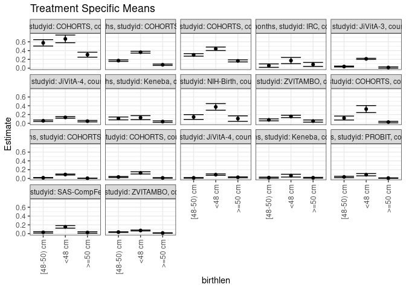

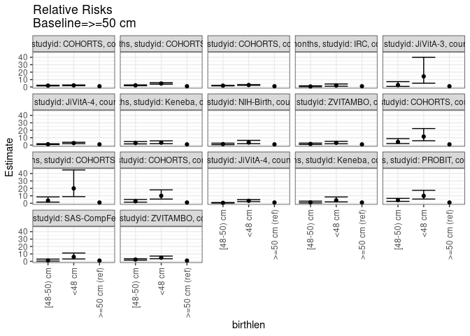

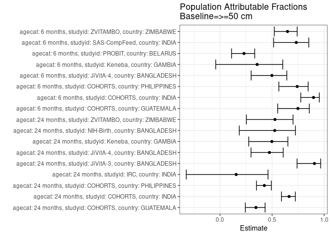

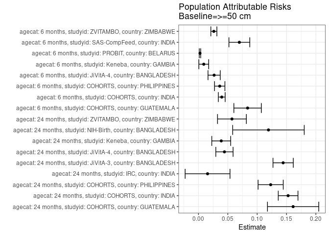

## Results Table

### Parameter: TSM

| agecat | studyid | country | intervention_level | baseline_level | estimate | ci_lower | ci_upper |
| --- | --- | --- | --- | --- | --- | --- | --- |
| 6 months | COHORTS | GUATEMALA | >=50 cm | NA | 0.0282287 | 0.0108265 | 0.0456309 |
| 6 months | COHORTS | GUATEMALA | <48 cm | NA | 0.3240299 | 0.2442204 | 0.4038393 |
| 6 months | COHORTS | GUATEMALA | [48-50) cm | NA | 0.1202783 | 0.0755050 | 0.1650517 |
| 6 months | COHORTS | INDIA | >=50 cm | NA | 0.0045113 | 0.0009094 | 0.0081131 |
| 6 months | COHORTS | INDIA | <48 cm | NA | 0.0901186 | 0.0789596 | 0.1012775 |
| 6 months | COHORTS | INDIA | [48-50) cm | NA | 0.0162637 | 0.0110657 | 0.0214618 |
| 6 months | COHORTS | PHILIPPINES | >=50 cm | NA | 0.0126510 | 0.0057134 | 0.0195887 |
| 6 months | COHORTS | PHILIPPINES | <48 cm | NA | 0.1271485 | 0.1019892 | 0.1523078 |
| 6 months | COHORTS | PHILIPPINES | [48-50) cm | NA | 0.0338422 | 0.0227933 | 0.0448912 |
| 6 months | JiVitA-4 | BANGLADESH | >=50 cm | NA | 0.0268270 | 0.0174051 | 0.0362488 |
| 6 months | JiVitA-4 | BANGLADESH | <48 cm | NA | 0.0874409 | 0.0707960 | 0.1040858 |
| 6 months | JiVitA-4 | BANGLADESH | [48-50) cm | NA | 0.0140020 | 0.0065379 | 0.0214661 |
| 6 months | Keneba | GAMBIA | >=50 cm | NA | 0.0162482 | 0.0067211 | 0.0257752 |
| 6 months | Keneba | GAMBIA | <48 cm | NA | 0.0641026 | 0.0327081 | 0.0954970 |
| 6 months | Keneba | GAMBIA | [48-50) cm | NA | 0.0183486 | 0.0057464 | 0.0309508 |
| 6 months | PROBIT | BELARUS | >=50 cm | NA | 0.0086482 | 0.0033862 | 0.0139101 |
| 6 months | PROBIT | BELARUS | <48 cm | NA | 0.0856960 | 0.0601199 | 0.1112720 |
| 6 months | PROBIT | BELARUS | [48-50) cm | NA | 0.0356192 | 0.0203355 | 0.0509028 |
| 6 months | SAS-CompFeed | INDIA | >=50 cm | NA | 0.0255102 | 0.0084713 | 0.0425492 |
| 6 months | SAS-CompFeed | INDIA | <48 cm | NA | 0.1537377 | 0.1251875 | 0.1822879 |
| 6 months | SAS-CompFeed | INDIA | [48-50) cm | NA | 0.0286396 | 0.0129545 | 0.0443247 |
| 6 months | ZVITAMBO | ZIMBABWE | >=50 cm | NA | 0.0142522 | 0.0096240 | 0.0188804 |
| 6 months | ZVITAMBO | ZIMBABWE | <48 cm | NA | 0.0713969 | 0.0616470 | 0.0811469 |
| 6 months | ZVITAMBO | ZIMBABWE | [48-50) cm | NA | 0.0347519 | 0.0285085 | 0.0409953 |
| 24 months | COHORTS | GUATEMALA | >=50 cm | NA | 0.3066166 | 0.2502627 | 0.3629705 |
| 24 months | COHORTS | GUATEMALA | <48 cm | NA | 0.6665041 | 0.5796976 | 0.7533105 |
| 24 months | COHORTS | GUATEMALA | [48-50) cm | NA | 0.5760280 | 0.5032763 | 0.6487798 |
| 24 months | COHORTS | INDIA | >=50 cm | NA | 0.0776195 | 0.0616406 | 0.0935983 |
| 24 months | COHORTS | INDIA | <48 cm | NA | 0.3627396 | 0.3417590 | 0.3837202 |
| 24 months | COHORTS | INDIA | [48-50) cm | NA | 0.1716022 | 0.1543479 | 0.1888566 |
| 24 months | COHORTS | PHILIPPINES | >=50 cm | NA | 0.1661003 | 0.1422627 | 0.1899378 |
| 24 months | COHORTS | PHILIPPINES | <48 cm | NA | 0.4414075 | 0.4024508 | 0.4803642 |
| 24 months | COHORTS | PHILIPPINES | [48-50) cm | NA | 0.3018409 | 0.2729592 | 0.3307226 |
| 24 months | IRC | INDIA | >=50 cm | NA | 0.0845070 | 0.0386997 | 0.1303144 |
| 24 months | IRC | INDIA | <48 cm | NA | 0.1727273 | 0.1019956 | 0.2434590 |
| 24 months | IRC | INDIA | [48-50) cm | NA | 0.0579710 | 0.0189316 | 0.0970105 |
| 24 months | JiVitA-3 | BANGLADESH | >=50 cm | NA | 0.0148515 | -0.0004421 | 0.0301450 |
| 24 months | JiVitA-3 | BANGLADESH | <48 cm | NA | 0.2117624 | 0.1987696 | 0.2247552 |
| 24 months | JiVitA-3 | BANGLADESH | [48-50) cm | NA | 0.0373614 | 0.0276804 | 0.0470423 |
| 24 months | JiVitA-4 | BANGLADESH | >=50 cm | NA | 0.0490630 | 0.0334655 | 0.0646605 |
| 24 months | JiVitA-4 | BANGLADESH | <48 cm | NA | 0.1348674 | 0.1169298 | 0.1528050 |
| 24 months | JiVitA-4 | BANGLADESH | [48-50) cm | NA | 0.0579205 | 0.0407186 | 0.0751225 |
| 24 months | Keneba | GAMBIA | >=50 cm | NA | 0.0391592 | 0.0223805 | 0.0559378 |
| 24 months | Keneba | GAMBIA | <48 cm | NA | 0.1289396 | 0.0831427 | 0.1747364 |
| 24 months | Keneba | GAMBIA | [48-50) cm | NA | 0.1109890 | 0.0781162 | 0.1438618 |
| 24 months | NIH-Birth | BANGLADESH | >=50 cm | NA | 0.1078023 | 0.0453542 | 0.1702504 |
| 24 months | NIH-Birth | BANGLADESH | <48 cm | NA | 0.3735576 | 0.2981315 | 0.4489837 |
| 24 months | NIH-Birth | BANGLADESH | [48-50) cm | NA | 0.1431430 | 0.0879990 | 0.1982869 |
| 24 months | ZVITAMBO | ZIMBABWE | >=50 cm | NA | 0.0511570 | 0.0265162 | 0.0757978 |
| 24 months | ZVITAMBO | ZIMBABWE | <48 cm | NA | 0.1570276 | 0.1301554 | 0.1838997 |
| 24 months | ZVITAMBO | ZIMBABWE | [48-50) cm | NA | 0.0789424 | 0.0571015 | 0.1007832 |

### Parameter: E(Y)

| agecat | studyid | country | intervention_level | baseline_level | estimate | ci_lower | ci_upper |
| --- | --- | --- | --- | --- | --- | --- | --- |
| 6 months | COHORTS | GUATEMALA | NA | NA | 0.1119186 | 0.0883438 | 0.1354934 |
| 6 months | COHORTS | INDIA | NA | NA | 0.0441728 | 0.0390306 | 0.0493149 |
| 6 months | COHORTS | PHILIPPINES | NA | NA | 0.0488708 | 0.0407385 | 0.0570030 |
| 6 months | JiVitA-4 | BANGLADESH | NA | NA | 0.0534826 | 0.0450763 | 0.0618888 |
| 6 months | Keneba | GAMBIA | NA | NA | 0.0252413 | 0.0168616 | 0.0336210 |
| 6 months | PROBIT | BELARUS | NA | NA | 0.0112310 | 0.0054733 | 0.0169886 |
| 6 months | SAS-CompFeed | INDIA | NA | NA | 0.0951662 | 0.0766361 | 0.1136962 |
| 6 months | ZVITAMBO | ZIMBABWE | NA | NA | 0.0404570 | 0.0362870 | 0.0446270 |
| 24 months | COHORTS | GUATEMALA | NA | NA | 0.4678571 | 0.4264941 | 0.5092202 |
| 24 months | COHORTS | INDIA | NA | NA | 0.2303489 | 0.2183836 | 0.2423141 |
| 24 months | COHORTS | PHILIPPINES | NA | NA | 0.2891073 | 0.2711229 | 0.3070917 |
| 24 months | IRC | INDIA | NA | NA | 0.1000000 | 0.0701878 | 0.1298122 |
| 24 months | JiVitA-3 | BANGLADESH | NA | NA | 0.1591036 | 0.1492688 | 0.1689383 |
| 24 months | JiVitA-4 | BANGLADESH | NA | NA | 0.0933032 | 0.0829251 | 0.1036813 |
| 24 months | Keneba | GAMBIA | NA | NA | 0.0779343 | 0.0618270 | 0.0940416 |
| 24 months | NIH-Birth | BANGLADESH | NA | NA | 0.2270531 | 0.1866503 | 0.2674560 |
| 24 months | ZVITAMBO | ZIMBABWE | NA | NA | 0.1082090 | 0.0930209 | 0.1233971 |

### Parameter: RR

| agecat | studyid | country | intervention_level | baseline_level | estimate | ci_lower | ci_upper |
| --- | --- | --- | --- | --- | --- | --- | --- |
| 6 months | COHORTS | GUATEMALA | >=50 cm | >=50 cm | 1.0000000 | 1.0000000 | 1.0000000 |
| 6 months | COHORTS | GUATEMALA | <48 cm | >=50 cm | 11.4787410 | 5.9118900 | 22.2875416 |
| 6 months | COHORTS | GUATEMALA | [48-50) cm | >=50 cm | 4.2608532 | 2.0732690 | 8.7566399 |
| 6 months | COHORTS | INDIA | >=50 cm | >=50 cm | 1.0000000 | 1.0000000 | 1.0000000 |
| 6 months | COHORTS | INDIA | <48 cm | >=50 cm | 19.9762846 | 8.9048026 | 44.8131154 |
| 6 months | COHORTS | INDIA | [48-50) cm | >=50 cm | 3.6051282 | 1.5255447 | 8.5195470 |
| 6 months | COHORTS | PHILIPPINES | >=50 cm | >=50 cm | 1.0000000 | 1.0000000 | 1.0000000 |
| 6 months | COHORTS | PHILIPPINES | <48 cm | >=50 cm | 10.0504333 | 5.6136443 | 17.9938743 |
| 6 months | COHORTS | PHILIPPINES | [48-50) cm | >=50 cm | 2.6750547 | 1.4135031 | 5.0625411 |
| 6 months | JiVitA-4 | BANGLADESH | >=50 cm | >=50 cm | 1.0000000 | 1.0000000 | 1.0000000 |
| 6 months | JiVitA-4 | BANGLADESH | <48 cm | >=50 cm | 3.2594408 | 2.1912614 | 4.8483280 |
| 6 months | JiVitA-4 | BANGLADESH | [48-50) cm | >=50 cm | 0.5219374 | 0.2737140 | 0.9952674 |
| 6 months | Keneba | GAMBIA | >=50 cm | >=50 cm | 1.0000000 | 1.0000000 | 1.0000000 |
| 6 months | Keneba | GAMBIA | <48 cm | >=50 cm | 3.9452214 | 1.8377214 | 8.4696038 |
| 6 months | Keneba | GAMBIA | [48-50) cm | >=50 cm | 1.1292744 | 0.4577236 | 2.7860931 |
| 6 months | PROBIT | BELARUS | >=50 cm | >=50 cm | 1.0000000 | 1.0000000 | 1.0000000 |
| 6 months | PROBIT | BELARUS | <48 cm | >=50 cm | 9.9091465 | 5.6523996 | 17.3715928 |
| 6 months | PROBIT | BELARUS | [48-50) cm | >=50 cm | 4.1186977 | 2.5732994 | 6.5921869 |
| 6 months | SAS-CompFeed | INDIA | >=50 cm | >=50 cm | 1.0000000 | 1.0000000 | 1.0000000 |
| 6 months | SAS-CompFeed | INDIA | <48 cm | >=50 cm | 6.0265162 | 3.2342085 | 11.2296091 |
| 6 months | SAS-CompFeed | INDIA | [48-50) cm | >=50 cm | 1.1226730 | 0.4128721 | 3.0527484 |
| 6 months | ZVITAMBO | ZIMBABWE | >=50 cm | >=50 cm | 1.0000000 | 1.0000000 | 1.0000000 |
| 6 months | ZVITAMBO | ZIMBABWE | <48 cm | >=50 cm | 5.0095206 | 3.5221770 | 7.1249392 |
| 6 months | ZVITAMBO | ZIMBABWE | [48-50) cm | >=50 cm | 2.4383439 | 1.6824852 | 3.5337731 |
| 24 months | COHORTS | GUATEMALA | >=50 cm | >=50 cm | 1.0000000 | 1.0000000 | 1.0000000 |
| 24 months | COHORTS | GUATEMALA | <48 cm | >=50 cm | 2.1737377 | 1.7362810 | 2.7214117 |
| 24 months | COHORTS | GUATEMALA | [48-50) cm | >=50 cm | 1.8786590 | 1.5050033 | 2.3450842 |
| 24 months | COHORTS | INDIA | >=50 cm | >=50 cm | 1.0000000 | 1.0000000 | 1.0000000 |
| 24 months | COHORTS | INDIA | <48 cm | >=50 cm | 4.6733080 | 3.7773418 | 5.7817929 |
| 24 months | COHORTS | INDIA | [48-50) cm | >=50 cm | 2.2108148 | 1.7613622 | 2.7749558 |
| 24 months | COHORTS | PHILIPPINES | >=50 cm | >=50 cm | 1.0000000 | 1.0000000 | 1.0000000 |
| 24 months | COHORTS | PHILIPPINES | <48 cm | >=50 cm | 2.6574762 | 2.2488025 | 3.1404179 |
| 24 months | COHORTS | PHILIPPINES | [48-50) cm | >=50 cm | 1.8172210 | 1.5322058 | 2.1552537 |
| 24 months | IRC | INDIA | >=50 cm | >=50 cm | 1.0000000 | 1.0000000 | 1.0000000 |
| 24 months | IRC | INDIA | <48 cm | >=50 cm | 2.0439394 | 1.0361710 | 4.0318521 |
| 24 months | IRC | INDIA | [48-50) cm | >=50 cm | 0.6859903 | 0.2889866 | 1.6283892 |
| 24 months | JiVitA-3 | BANGLADESH | >=50 cm | >=50 cm | 1.0000000 | 1.0000000 | 1.0000000 |
| 24 months | JiVitA-3 | BANGLADESH | <48 cm | >=50 cm | 14.2586672 | 5.0919529 | 39.9276262 |
| 24 months | JiVitA-3 | BANGLADESH | [48-50) cm | >=50 cm | 2.5156645 | 0.8759202 | 7.2250511 |
| 24 months | JiVitA-4 | BANGLADESH | >=50 cm | >=50 cm | 1.0000000 | 1.0000000 | 1.0000000 |
| 24 months | JiVitA-4 | BANGLADESH | <48 cm | >=50 cm | 2.7488625 | 1.9568032 | 3.8615253 |
| 24 months | JiVitA-4 | BANGLADESH | [48-50) cm | >=50 cm | 1.1805347 | 0.7615950 | 1.8299254 |
| 24 months | Keneba | GAMBIA | >=50 cm | >=50 cm | 1.0000000 | 1.0000000 | 1.0000000 |
| 24 months | Keneba | GAMBIA | <48 cm | >=50 cm | 3.2927062 | 1.8880135 | 5.7424983 |
| 24 months | Keneba | GAMBIA | [48-50) cm | >=50 cm | 2.8343044 | 1.6852634 | 4.7667812 |
| 24 months | NIH-Birth | BANGLADESH | >=50 cm | >=50 cm | 1.0000000 | 1.0000000 | 1.0000000 |
| 24 months | NIH-Birth | BANGLADESH | <48 cm | >=50 cm | 3.4652113 | 1.8789263 | 6.3907186 |
| 24 months | NIH-Birth | BANGLADESH | [48-50) cm | >=50 cm | 1.3278290 | 0.6639930 | 2.6553438 |
| 24 months | ZVITAMBO | ZIMBABWE | >=50 cm | >=50 cm | 1.0000000 | 1.0000000 | 1.0000000 |
| 24 months | ZVITAMBO | ZIMBABWE | <48 cm | >=50 cm | 3.0695231 | 1.8413615 | 5.1168509 |
| 24 months | ZVITAMBO | ZIMBABWE | [48-50) cm | >=50 cm | 1.5431397 | 0.8860203 | 2.6876132 |

### Parameter: PAR

| agecat | studyid | country | intervention_level | baseline_level | estimate | ci_lower | ci_upper |
| --- | --- | --- | --- | --- | --- | --- | --- |
| 6 months | COHORTS | GUATEMALA | >=50 cm | NA | 0.0836899 | 0.0602827 | 0.1070971 |
| 6 months | COHORTS | INDIA | >=50 cm | NA | 0.0396615 | 0.0338486 | 0.0454744 |
| 6 months | COHORTS | PHILIPPINES | >=50 cm | NA | 0.0362197 | 0.0273785 | 0.0450610 |
| 6 months | JiVitA-4 | BANGLADESH | >=50 cm | NA | 0.0266556 | 0.0162257 | 0.0370856 |
| 6 months | Keneba | GAMBIA | >=50 cm | NA | 0.0089931 | 0.0006416 | 0.0173447 |
| 6 months | PROBIT | BELARUS | >=50 cm | NA | 0.0025828 | 0.0014174 | 0.0037482 |
| 6 months | SAS-CompFeed | INDIA | >=50 cm | NA | 0.0696560 | 0.0518817 | 0.0874302 |
| 6 months | ZVITAMBO | ZIMBABWE | >=50 cm | NA | 0.0262048 | 0.0210761 | 0.0313335 |
| 24 months | COHORTS | GUATEMALA | >=50 cm | NA | 0.1612405 | 0.1175611 | 0.2049200 |
| 24 months | COHORTS | INDIA | >=50 cm | NA | 0.1527294 | 0.1359429 | 0.1695160 |
| 24 months | COHORTS | PHILIPPINES | >=50 cm | NA | 0.1230070 | 0.1015918 | 0.1444222 |
| 24 months | IRC | INDIA | >=50 cm | NA | 0.0154930 | -0.0227050 | 0.0536909 |
| 24 months | JiVitA-3 | BANGLADESH | >=50 cm | NA | 0.1442521 | 0.1269500 | 0.1615542 |
| 24 months | JiVitA-4 | BANGLADESH | >=50 cm | NA | 0.0442403 | 0.0295248 | 0.0589557 |
| 24 months | Keneba | GAMBIA | >=50 cm | NA | 0.0387751 | 0.0226701 | 0.0548801 |
| 24 months | NIH-Birth | BANGLADESH | >=50 cm | NA | 0.1192509 | 0.0583043 | 0.1801975 |
| 24 months | ZVITAMBO | ZIMBABWE | >=50 cm | NA | 0.0570520 | 0.0324943 | 0.0816097 |

### Parameter: PAF

| agecat | studyid | country | intervention_level | baseline_level | estimate | ci_lower | ci_upper |
| --- | --- | --- | --- | --- | --- | --- | --- |
| 6 months | COHORTS | GUATEMALA | >=50 cm | NA | 0.7477748 | 0.5535444 | 0.8575053 |
| 6 months | COHORTS | INDIA | >=50 cm | NA | 0.8978720 | 0.7751591 | 0.9536111 |
| 6 months | COHORTS | PHILIPPINES | >=50 cm | NA | 0.7411328 | 0.5647326 | 0.8460435 |
| 6 months | JiVitA-4 | BANGLADESH | >=50 cm | NA | 0.4983981 | 0.2982425 | 0.6414653 |
| 6 months | Keneba | GAMBIA | >=50 cm | NA | 0.3562864 | -0.0415418 | 0.6021598 |
| 6 months | PROBIT | BELARUS | >=50 cm | NA | 0.2299711 | 0.1110393 | 0.3329914 |
| 6 months | SAS-CompFeed | INDIA | >=50 cm | NA | 0.7319404 | 0.5143576 | 0.8520394 |
| 6 months | ZVITAMBO | ZIMBABWE | >=50 cm | NA | 0.6477191 | 0.5210217 | 0.7409030 |
| 24 months | COHORTS | GUATEMALA | >=50 cm | NA | 0.3446363 | 0.2428810 | 0.4327158 |
| 24 months | COHORTS | INDIA | >=50 cm | NA | 0.6630353 | 0.5899334 | 0.7231053 |
| 24 months | COHORTS | PHILIPPINES | >=50 cm | NA | 0.4254718 | 0.3494375 | 0.4926197 |
| 24 months | IRC | INDIA | >=50 cm | NA | 0.1549296 | -0.3244291 | 0.4607910 |
| 24 months | JiVitA-3 | BANGLADESH | >=50 cm | NA | 0.9066552 | 0.7397900 | 0.9665146 |
| 24 months | JiVitA-4 | BANGLADESH | >=50 cm | NA | 0.4741557 | 0.2972850 | 0.6065087 |
| 24 months | Keneba | GAMBIA | >=50 cm | NA | 0.4975362 | 0.2753933 | 0.6515766 |
| 24 months | NIH-Birth | BANGLADESH | >=50 cm | NA | 0.5252113 | 0.1842238 | 0.7236690 |
| 24 months | ZVITAMBO | ZIMBABWE | >=50 cm | NA | 0.5272388 | 0.2529885 | 0.7008036 |